# Chapter 8: Effect Sizes and Practical Interpretation

2026-02-25

# 1 Beyond p-values

A statistically significant result ($p < 0.05$) answers one narrow question: *“Is it unlikely that this result occurred by chance?”* It says nothing about whether the result is **meaningful** or **useful** in the real world.

> **The problem with p-values alone:** With a large enough sample, even a trivially small difference will produce $p < 0.05$. A drug that lowers blood pressure by 0.1 mmHg might be “statistically significant” in a trial of 100,000 patients — yet clinically irrelevant.

## 1.1 Statistical vs Practical Significance

| Term | Question it answers | Depends on |
| --- | --- | --- |
| **Statistical significance** | Is the effect real (not due to chance)? | Sample size $n$ and the effect |
| **Practical significance** | Is the effect large enough to matter? | The magnitude of the effect only |

The two can diverge dramatically:

- **Large $n$, tiny effect:** Statistically significant, practically irrelevant.
- **Small $n$, large effect:** Not statistically significant, yet potentially important.

**Effect size** bridges this gap — it quantifies *how big* an effect is, independent of sample size.

# 2 Effect Size Measures

## 2.1 Cohen’s *d* — for Comparing Two Means

**Cohen’s *d*** measures the standardised difference between two group means: how many standard deviations apart are the groups?

$$d = \frac{\bar{x}_1 -
\bar{x}_2}{s_{\text{pooled}}}, \quad s_{\text{pooled}} =
\sqrt{\frac{s_1^2 + s_2^2}{2}}$$

### 2.1.1 Interpretation benchmarks (Cohen, 1988)

| $\|d\|$ | Effect size | Real-world analogy |
| --- | --- | --- |
| $\approx 0.2$ | Small | Difference between heights of 15- and 16-year-old girls |
| $\approx 0.5$ | Medium | Difference in IQ between clerical and semi-skilled workers |
| $\approx 0.8$ | Large | Difference in IQ between PhD holders and typical college freshmen |

> **Rule of thumb:** Report the effect size alongside every p-value. A result can be statistically significant and practically small ($d = 0.1$), or statistically non-significant and practically large ($d = 0.9$ with $n = 5$).

## 2.2 Phi Coefficient ($\phi$) — for Categorical Data

The **phi coefficient** measures the strength of association between two **binary categorical variables** in a 2×2 contingency table.

$$\phi =
\sqrt{\frac{\chi^2}{n}}$$

where $\chi^2$ is the chi-squared test statistic and $n$ is the total sample size.

| $\|\phi\|$ | Association strength |
| --- | --- |
| $0.1$ | Weak |
| $0.3$ | Moderate |
| $0.5$ | Strong |

For larger contingency tables ($r \times c$), use **Cramér’s V**:

$$V = \sqrt{\frac{\chi^2}{n \cdot
\min(r-1,\; c-1)}}$$

# 3 R Coverage

## 3.1 Manual Computation of Cohen’s *d*

```r
group1 <- c(20, 22, 21, 23, 24)
group2 <- c(10, 11, 12, 13, 14)

# Means
mean1 <- mean(group1)
mean2 <- mean(group2)

# Pooled standard deviation
pooled_sd <- sqrt((var(group1) + var(group2)) / 2)

# Cohen's d
cohen_d <- (mean1 - mean2) / pooled_sd

cat("Mean Group 1       :", mean1, "\n")
```

```
#> Mean Group 1       : 22
```

```r
cat("Mean Group 2       :", mean2, "\n")
```

```
#> Mean Group 2       : 12
```

```r
cat("Pooled SD          :", round(pooled_sd, 4), "\n")
```

```
#> Pooled SD          : 1.5811
```

```r
cat("Cohen's d          :", round(cohen_d, 4), "\n")
```

```
#> Cohen's d          : 6.3246
```

```r
cat("Interpretation     :",
    ifelse(abs(cohen_d) >= 0.8, "Large",
    ifelse(abs(cohen_d) >= 0.5, "Medium", "Small")), "effect\n")
```

```
#> Interpretation     : Large effect
```

## 3.2 Computing Phi and Cramér’s V

```r
# 2×2 contingency table
data_table <- matrix(c(30, 20, 25, 25),
                     nrow = 2, byrow = TRUE,
                     dimnames = list(Group     = c("A", "B"),
                                     Outcome   = c("Yes", "No")))

chi_result <- chisq.test(data_table)
n_total    <- sum(data_table)

# Phi coefficient (2×2 tables only)
phi <- sqrt(chi_result$statistic / n_total)

# Cramér's V (generalises to any r×c table)
k       <- min(nrow(data_table) - 1, ncol(data_table) - 1)
cramer_v <- sqrt(chi_result$statistic / (n_total * k))

cat("χ² statistic  :", round(chi_result$statistic, 4), "\n")
```

```
#> χ² statistic  : 0.6465
```

```r
cat("p-value       :", round(chi_result$p.value, 4), "\n")
```

```
#> p-value       : 0.4214
```

```r
cat("Phi (φ)       :", round(phi, 4), "\n")
```

```
#> Phi (φ)       : 0.0804
```

```r
cat("Cramér's V    :", round(cramer_v, 4), "\n")
```

```
#> Cramér's V    : 0.0804
```

## 3.3 Validation via Bootstrap Simulation

Bootstrap simulation estimates the **sampling distribution of Cohen’s *d***, giving us a confidence interval around the point estimate.

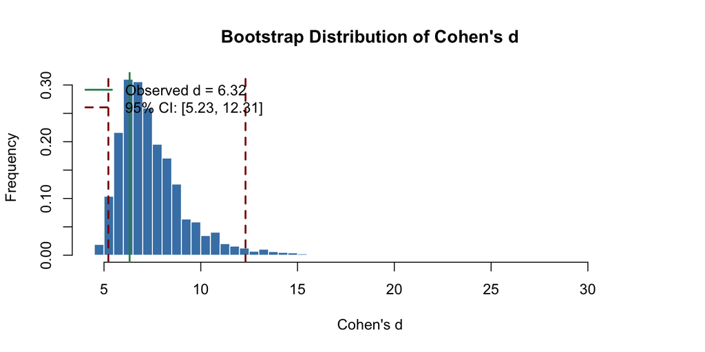

```r
set.seed(123)

n_sims           <- 10000
simulated_d      <- numeric(n_sims)

for (i in 1:n_sims) {
  s1 <- sample(group1, length(group1), replace = TRUE)
  s2 <- sample(group2, length(group2), replace = TRUE)
  simulated_d[i] <- (mean(s1) - mean(s2)) /
                     sqrt((var(s1) + var(s2)) / 2)
}

# Bootstrap 95% CI for Cohen's d
boot_ci <- quantile(simulated_d, probs = c(0.025, 0.975))

hist(simulated_d,
     breaks = 50,
     col    = "steelblue",
     border = "white",
     main   = "Bootstrap Distribution of Cohen's d",
     xlab   = "Cohen's d",
     ylab   = "Frequency",
     freq   = FALSE)

abline(v = cohen_d,      col = "seagreen", lwd = 2)
abline(v = boot_ci,      col = "darkred",  lwd = 2, lty = 2)

legend("topleft",
       legend = c(paste0("Observed d = ", round(cohen_d, 2)),
                  paste0("95% CI: [", round(boot_ci[1], 2),
                         ", ", round(boot_ci[2], 2), "]")),
       col    = c("seagreen", "darkred"),
       lwd    = 2, lty = c(1, 2), bty = "n")
```

```r
cat("Bootstrap 95% CI for Cohen's d: [",
    round(boot_ci[1], 3), ",", round(boot_ci[2], 3), "]\n")
```

```
#> Bootstrap 95% CI for Cohen's d: [ 5.225 , 12.312 ]
```

## 3.4 The Effect of Sample Size on p-values vs Effect Size

This simulation directly demonstrates why reporting effect size alongside p-values matters.

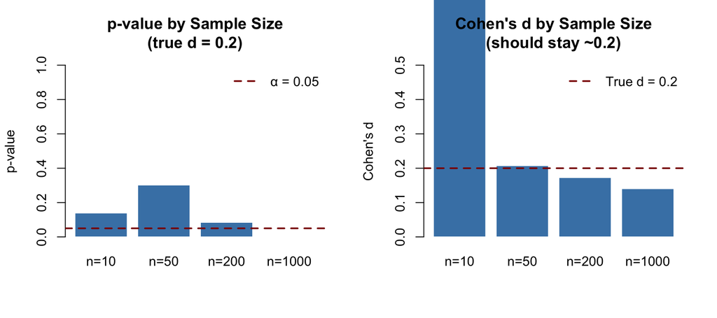

```r
set.seed(42)

# True population difference is small but fixed
true_d  <- 0.2          # small effect
ns      <- c(10, 50, 200, 1000)
results <- data.frame(n = ns, p_value = NA, cohens_d = NA)

for (i in seq_along(ns)) {
  n  <- ns[i]
  g1 <- rnorm(n, mean = 0.2, sd = 1)
  g2 <- rnorm(n, mean = 0.0, sd = 1)
  tt <- t.test(g1, g2)
  ps <- sqrt((var(g1) + var(g2)) / 2)

  results$p_value[i]  <- tt$p.value
  results$cohens_d[i] <- (mean(g1) - mean(g2)) / ps
}

par(mfrow = c(1, 2))

# p-value shrinks with n even though effect is constant
barplot(results$p_value,
        names.arg = paste0("n=", ns),
        col       = ifelse(results$p_value < 0.05, "tomato", "steelblue"),
        border    = "white",
        main      = "p-value by Sample Size\n(true d = 0.2)",
        ylab      = "p-value",
        ylim      = c(0, 1))
abline(h = 0.05, col = "darkred", lwd = 2, lty = 2)
legend("topright", legend = "α = 0.05",
       col = "darkred", lty = 2, lwd = 2, bty = "n")

# Cohen's d stays stable regardless of n
barplot(results$cohens_d,
        names.arg = paste0("n=", ns),
        col       = "steelblue",
        border    = "white",
        main      = "Cohen's d by Sample Size\n(should stay ~0.2)",
        ylab      = "Cohen's d",
        ylim      = c(0, 0.5))
abline(h = 0.2, col = "darkred", lwd = 2, lty = 2)
legend("topright", legend = "True d = 0.2",
       col = "darkred", lty = 2, lwd = 2, bty = "n")
```

```r
par(mfrow = c(1, 1))
```

## 3.5 Reporting Standards

A complete, transparent statistical report should include:

```r
# Full reporting template
cat("=== Statistical Report ===\n\n")
```

```
#> === Statistical Report ===
```

```r
cat("Test           : Independent two-sample t-test\n")
```

```
#> Test           : Independent two-sample t-test
```

```r
cat("Groups         : Group 1 (n =", length(group1),
    ") vs Group 2 (n =", length(group2), ")\n")
```

```
#> Groups         : Group 1 (n = 5 ) vs Group 2 (n = 5 )
```

```r
cat("Means          :", mean1, "vs", mean2, "\n")
```

```
#> Means          : 22 vs 12
```

```r
cat("t-statistic    :", round(t.test(group1, group2)$statistic, 3), "\n")
```

```
#> t-statistic    : 10
```

```r
cat("p-value        :", round(t.test(group1, group2)$p.value, 4), "\n")
```

```
#> p-value        : 0
```

```r
cat("95% CI for diff:",
    round(t.test(group1, group2)$conf.int[1], 3), "to",
    round(t.test(group1, group2)$conf.int[2], 3), "\n")
```

```
#> 95% CI for diff: 7.694 to 12.306
```

```r
cat("Cohen's d      :", round(cohen_d, 3), "(Large effect)\n")
```

```
#> Cohen's d      : 6.325 (Large effect)
```

```r
cat("Bootstrap 95% CI for d: [",
    round(boot_ci[1], 3), ",", round(boot_ci[2], 3), "]\n")
```

```
#> Bootstrap 95% CI for d: [ 5.225 , 12.312 ]
```

### 3.5.1 Reporting checklist

| Item | Why it matters |
| --- | --- |
| Test name and type | Reproducibility; reader can verify |
| Sample sizes ($n_1$, $n_2$) | Assesses statistical power |
| Test statistic ($t$, $\chi^2$, $z$) | Shows the raw evidence |
| p-value | Probability of result under $H_0$ |
| Confidence interval | Range of plausible true values |
| Effect size ($d$, $\phi$, $V$) | Practical magnitude, independent of $n$ |
| Effect size CI (if possible) | Uncertainty around the effect estimate |

# 4 Chapter Summary

[output not shown]